# BIOM262 - eQTL mapping

## Genotype data and sample information

We will use genotyping data from the 1000 genomes project. Specifically we will use genotypes from Yoruba individuals from Nigeria

### Read Samples

Read in the identifiers of the samples. Each sample is an immortalized lymphoblastoid cell line derived from a different Yoruba individual.

```r
# use 'as.characeter' to make sure we have the sample names as a vector of character strings (rather than
# a factor)
sample.tab <- read.table("../Data/samples.txt", header=F)
sample.names <- as.character(sample.tab$V1)
head(sample.names)
```

```
[1] "NA18520" "NA19225" "NA19143" "NA19201" "NA19144" "NA19147"
```

### Read Genotypes

```r
genotypes.tab <- read.table("../Data/chr22_genotypes.txt", header=T)
head(genotypes.tab)
```

|  | SNP.ID | CHROM | CHROM.POS | ALLELE1 | ALLELE2 | NA18520 | NA19225 | NA19143 | NA19201 | NA19144 | NA19147 | NA19160 | NA18861 | NA19098 | NA19206 | NA18909 | NA18498 | NA18907 | NA19141 | NA19130 | NA19131 | NA18517 | NA19119 | NA18511 | NA18510 | NA19209 | NA19137 | NA19138 | NA19152 | … |
| --- | --- | --- | --- | --- | --- | --- | --- | --- | --- | --- | --- | --- | --- | --- | --- | --- | --- | --- | --- | --- | --- | --- | --- | --- | --- | --- | --- | --- | --- | --- |
| 1 | rs587755077 | chr22 | 16050115 | G | A | 0 | 0 | 0 | 0 | 0 | 0 | 0 | 0 | 0 | 0 | 0 | 0 | 0 | 0 | 0 | 0 | 0 | 0 | 0 | 0 | 0 | 1 | 0 | 0 | … |
| 2 | rs587654921 | chr22 | 16050213 | C | T | 0 | 0 | 0 | 0 | 0 | 0 | 0 | 0 | 0 | 0 | 0 | 0 | 0 | 0 | 0 | 0 | 0 | 0 | 0 | 0 | 0 | 0 | 0 | 0 | … |
| 3 | rs587747231 | chr22 | 16050739 | TA | T | 0 | 0 | 0 | 0 | 0 | 0 | 0 | 0 | 0 | 0 | 0 | 0 | 0 | 0 | 0 | 0 | 0 | 0 | 0 | 0 | 0 | 0 | 0 | 0 | … |
| 4 | rs587743568 | chr22 | 16050783 | A | G | 0 | 0 | 0 | 0 | 0 | 0 | 0 | 0 | 0 | 0 | 0 | 0 | 0 | 0 | 0 | 0 | 0 | 0 | 0 | 0 | 0 | 0 | 0 | 0 | … |
| 5 | rs188945759 | chr22 | 16050984 | C | G | 0 | 0 | 0 | 0 | 0 | 0 | 0 | 0 | 0 | 0 | 0 | 0 | 0 | 0 | 0 | 0 | 0 | 0 | 0 | 0 | 0 | 0 | 0 | 0 | … |
| 6 | rs587723851 | chr22 | 16052032 | G | A | 0 | 0 | 0 | 0 | 0 | 0 | 0 | 0 | 0 | 0 | 0 | 0 | 0 | 0 | 0 | 0 | 0 | 0 | 0 | 0 | 0 | 0 | 0 | 0 | … |

```r
genotype.matrix <- genotypes.tab[,sample.names]
head(genotype.matrix)
```

|  | NA18520 | NA19225 | NA19143 | NA19201 | NA19144 | NA19147 | NA19160 | NA18861 | NA19098 | NA19206 | NA18909 | NA18498 | NA18907 | NA19141 | NA19130 | NA19131 | NA18517 | NA19119 | NA18511 | NA18510 | NA19209 | NA19137 | NA19138 | NA19152 | NA19257 | NA18519 | NA19114 | NA19153 | NA19190 | … |
| --- | --- | --- | --- | --- | --- | --- | --- | --- | --- | --- | --- | --- | --- | --- | --- | --- | --- | --- | --- | --- | --- | --- | --- | --- | --- | --- | --- | --- | --- | --- |
| 1 | 0 | 0 | 0 | 0 | 0 | 0 | 0 | 0 | 0 | 0 | 0 | 0 | 0 | 0 | 0 | 0 | 0 | 0 | 0 | 0 | 0 | 1 | 0 | 0 | 0 | 1 | 0 | 0 | 0 | … |
| 2 | 0 | 0 | 0 | 0 | 0 | 0 | 0 | 0 | 0 | 0 | 0 | 0 | 0 | 0 | 0 | 0 | 0 | 0 | 0 | 0 | 0 | 0 | 0 | 0 | 0 | 0 | 1 | 0 | 0 | … |
| 3 | 0 | 0 | 0 | 0 | 0 | 0 | 0 | 0 | 0 | 0 | 0 | 0 | 0 | 0 | 0 | 0 | 0 | 0 | 0 | 0 | 0 | 0 | 0 | 0 | 0 | 0 | 1 | 0 | 0 | … |
| 4 | 0 | 0 | 0 | 0 | 0 | 0 | 0 | 0 | 0 | 0 | 0 | 0 | 0 | 0 | 0 | 0 | 0 | 0 | 0 | 0 | 0 | 0 | 0 | 0 | 0 | 0 | 0 | 0 | 0 | … |
| 5 | 0 | 0 | 0 | 0 | 0 | 0 | 0 | 0 | 0 | 0 | 0 | 0 | 0 | 0 | 0 | 0 | 0 | 0 | 0 | 0 | 0 | 0 | 0 | 0 | 0 | 0 | 0 | 0 | 0 | … |
| 6 | 0 | 0 | 0 | 0 | 0 | 0 | 0 | 0 | 0 | 0 | 0 | 0 | 0 | 0 | 0 | 0 | 0 | 0 | 0 | 0 | 0 | 0 | 0 | 0 | 0 | 0 | 0 | 0 | 1 | … |

### Analyze genotype data

Here are a few questions to get people familiar with the genotype data

Q: How many samples are there?

```r
n.samples <- length(sample.names)
n.samples
```

```
[1] 53
```

Q: what is the chromosomal position and alleles of SNP rs55926024?

```r
snp.row <- genotypes.tab$SNP.ID == "rs55926024"
genotypes.tab[snp.row, c("CHROM", "CHROM.POS", "ALLELE1", "ALLELE2")]
```

|  | CHROM | CHROM.POS | ALLELE1 | ALLELE2 |
| --- | --- | --- | --- | --- |
| 25 | chr22 | 16054740 | A | G |

Q: How many individuals are heterozygous for SNP rs55926024?

```r
sum(genotype.matrix[snp.row,] == 1)
```

```
[1] 22
```

Q: What is the frequency of allele2 for rs55926024 in our samples?

```r
total.alleles <- n.samples * 2
sum(genotype.matrix[snp.row,]) / total.alleles
```

```
[1] 0.3584906
```

### Gene expression data

We will use RNA-seq gene expression data from the GEUVADIS project. The data are from the same Yoruba cell lines that we have genotypes for. The reads have already been mapped to the genome and the number of reads overlapping exons of Ensembl genes has computed.

## Read RNA-seq counts data

Read in mapped RNA-seq read counts for each gene. The first columns 5 give information about the gene. The subsequent columns that start with “NA” (e.g. NA18520) contain mapped read counts for each sample in the study.

```r
all.gene.tab <- read.table("../Data/gene_mapped_read_counts.txt", header=T)
head(all.gene.tab)
```

|  | GENE.NAME | CHROM | GENE.START | GENE.END | GENE.CDNA.LEN | NA18520 | NA19225 | NA19143 | NA19201 | NA19144 | NA19147 | NA19160 | NA18861 | NA19098 | NA19206 | NA18909 | NA18498 | NA18907 | NA19141 | NA19130 | NA19131 | NA18517 | NA19119 | NA18511 | NA18510 | NA19209 | NA19137 | NA19138 | NA19152 | … |
| --- | --- | --- | --- | --- | --- | --- | --- | --- | --- | --- | --- | --- | --- | --- | --- | --- | --- | --- | --- | --- | --- | --- | --- | --- | --- | --- | --- | --- | --- | --- |
| 1 | ENSG00000223972 | chr1 | 11869 | 14412 | 1756 | 0 | 0 | 0 | 2 | 0 | 0 | 0 | 17 | 0 | 1 | 0 | 1 | 2 | 2 | 2 | 0 | 0 | 0 | 0 | 0 | 0 | 0 | 0 | 2 | … |
| 2 | ENSG00000227232 | chr1 | 14363 | 29806 | 2073 | 105 | 475 | 541 | 291 | 1043 | 385 | 248 | 213 | 488 | 614 | 359 | 375 | 346 | 1152 | 488 | 867 | 320 | 362 | 874 | 304 | 740 | 308 | 178 | 420 | … |
| 3 | ENSG00000243485 | chr1 | 29554 | 31109 | 1021 | 0 | 0 | 0 | 0 | 0 | 0 | 0 | 6 | 0 | 0 | 0 | 0 | 0 | 0 | 0 | 1 | 0 | 0 | 0 | 0 | 0 | 0 | 0 | 0 | … |
| 4 | ENSG00000237613 | chr1 | 34554 | 36081 | 1219 | 0 | 0 | 0 | 0 | 0 | 0 | 0 | 0 | 0 | 0 | 0 | 0 | 0 | 0 | 0 | 0 | 0 | 0 | 0 | 0 | 0 | 0 | 0 | 0 | … |
| 5 | ENSG00000268020 | chr1 | 52473 | 54936 | 947 | 0 | 0 | 0 | 0 | 0 | 0 | 0 | 7 | 0 | 0 | 0 | 0 | 0 | 0 | 0 | 0 | 0 | 0 | 0 | 0 | 0 | 0 | 0 | 0 | … |
| 6 | ENSG00000240361 | chr1 | 62948 | 63887 | 940 | 0 | 0 | 0 | 0 | 0 | 0 | 0 | 16 | 0 | 0 | 0 | 0 | 0 | 0 | 0 | 0 | 0 | 0 | 0 | 0 | 0 | 0 | 0 | 0 | … |

## Compute TPM expression values

Create an expression matrix containing transcripts-per-million (TPM) as a measure of gene expression. Could alternatively use RPKM

Explanation of TPM from (see http://www.rna-seqblog.com/rpkm-fpkm-and-tpm-clearly-explained/): 1. Divide the read counts by the length of each gene in kilobases. This gives you reads per kilobase (RPK). 2. Count up all the RPK values in a sample and divide this number by 1,000,000. This is your âper millionâ scaling factor. 3. Divide the RPK values by the âper millionâ scaling factor. This gives you TPM.

```r
all.count.matrix <- all.gene.tab[,sample.names]
# compute RPK values for each gene
all.rpk.matrix <- all.count.matrix / (all.gene.tab$GENE.CDNA.LEN/1000)
# get column RPK totals, using apply function
rpk.sum <- apply(all.rpk.matrix, 2, sum)
# divide each column by per million scaling factor to get TPM
# Note: the following statement was corrected after class:
all.tpm.matrix <- t(t(all.rpk.matrix) / (rpk.sum/1e6))
```

## Analyze gene expression values

Q: How many genes are in the gene expression table?

```r
nrow(all.gene.tab)
```

```
[1] 63677
```

This is a lot of ‘genes’! The Ensembl ‘ENSG’ gene list contains many pseudo-genes, and low-expression lncRNAs etc.

Calculate mean expression across samples, then make a histogram of log TPM values for genes that have mean TPM > 0.0.

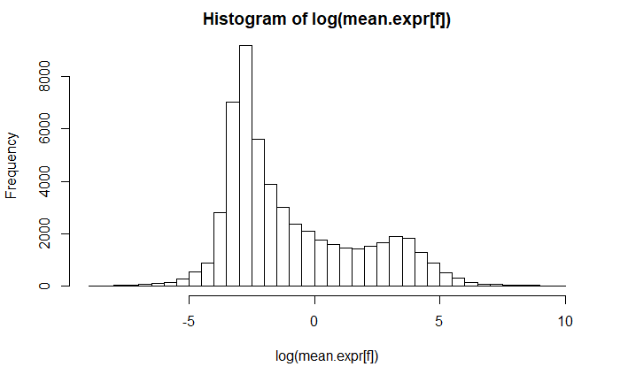

```r
mean.expr <- apply(all.tpm.matrix, 1, mean)
f <- mean.expr > 0.0
hist(log(mean.expr[f]), breaks=50)
```

The mean expression distribution is bimodal, with a large number of low-expression genes.

Q: How many genes have TPM values > 1.0?

```r
sum(mean.expr > 1)
```

```
[1] 16279
```

This is a reasonable number of genes to consider expressed in this cell type (lymphoblastoid cell lines). So lets discard all genes with TPM < 1.0 from further analyses.

## Other data pre-processing

There are additional steps we could take when processing the gene expression and genotype data.

- Correct for population structure by doing principal components analysis of genotype matrix (PCs could be used as co-variates in linear model)
- Correct for expression batch effects by regressing out PCs, performing quantile normalization

## identifying eQTLs

Get a set of genes that are on chr22 and that have TPM > 1.0

```r
f <- (all.gene.tab$CHROM == "chr22") & (mean.expr > 1.0)
gene.tab <- all.gene.tab[f,]
tpm.matrix <- all.tpm.matrix[f,]
head(tpm.matrix)
```

```
        NA18520    NA19225   NA19143   NA19201   NA19144   NA19147   NA19160    NA18861   NA19098    NA19206    NA18909
[1,]   1.095523  0.6743438  1.619055  1.490332  1.107839  3.006428  1.294602   1.993241  1.786052  0.9313380  1.5856162
[2,]  13.571016  4.0833678  3.945334 16.770337  3.603276 11.926507 11.885246   2.332533 14.343658  1.4852169  1.8718938
[3,]   2.549313  0.9910846  1.971609  4.509534  1.339868  2.913960  3.054301   2.406351  5.096807  0.4725583  0.3495576
[4,]  25.332926 13.6179424 14.254163 14.463574 11.190340 11.248107 15.276088  19.720573 19.064018 11.3899150 16.8632342
[5,]  25.299856 56.5985714 55.269386 26.493183 24.809306 47.600052 30.452445  52.254588 60.592383 31.7062115 50.8271469
[6,] 123.848134 73.3647320 66.665709 33.698014 44.462075 60.335367 97.583174 113.234346 87.586413 47.8269211 61.1867133
        NA18498     NA18907   NA19141    NA19130    NA19131    NA18517   NA19119     NA18511   NA18510   NA19209   NA19137
[1,]  1.7338732  0.68680872  1.574397  0.8071419  0.9861361  1.5119144  1.132109  0.48633972  1.543135  0.887123  0.373110
[2,]  3.6490678  0.06017141  5.263012  8.7994505  7.6424038  0.3642623  7.600821  0.10815951  5.337760  9.874449  7.146462
[3,]  0.9930787  0.00000000  3.687771  1.7793875  3.2156931  0.1169507  2.273947  0.06872833  2.794437  2.955295  1.610809
[4,] 15.0153343 14.96236144  7.917260 11.5559150 14.1877626 12.3524280 19.917917 14.12518852 14.333138 17.015363 23.901577
[5,] 37.9646062 53.51452521 45.546244 48.2975448 40.9105718 39.0310050 38.238754 44.48328100 48.372253 46.114832 41.510112
[6,] 72.9724674 81.76870210 31.382448 45.6646514 51.2176278 44.7272807 97.547039 61.85341900 64.746348 69.818560 78.853830
       NA19138    NA19152    NA19257   NA18519    NA19114   NA19153    NA19190   NA19200    NA19210    NA18505    NA19171
```

[output cut: 20 more lines]

Plot the expression of gene ENSG00000218537 (MIF-AS1) as a function of the genotype of the SNP rs5760108.

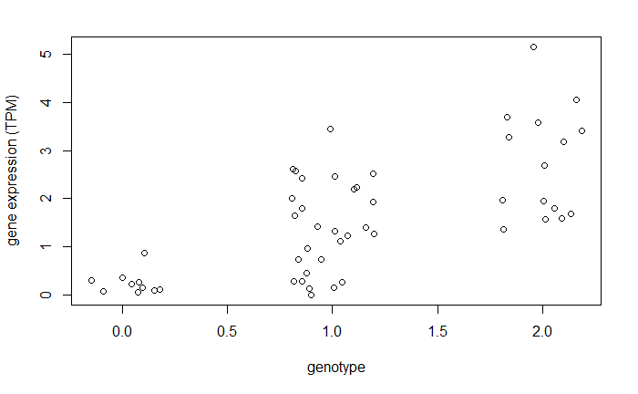

```r
expr <- unlist(tpm.matrix[gene.tab$GENE.NAME == "ENSG00000218537",])
genos <- unlist(genotype.matrix[genotypes.tab$SNP.ID == "rs5760108",])
plot(jitter(genos), expr, xlab="genotype", ylab="gene expression (TPM)")
```

Fit a linear model, using expression as the response and genotype as the predictor

```r
mdl <- lm(expr ~ genos)
summary(mdl)
```

```
Call:
lm(formula = expr ~ genos)

Residuals:
     Min       1Q   Median       3Q      Max
-1.44888 -0.73025 -0.04898  0.66507  2.46593

Coefficients:
            Estimate Std. Error t value Pr(>|t|)
(Intercept)   0.1976     0.2372   0.833    0.409
genos         1.2513     0.1841   6.797 1.14e-08 ***
---
Signif. codes:  0 *** 0.001 ** 0.01 * 0.05 . 0.1   1

Residual standard error: 0.9117 on 51 degrees of freedom
Multiple R-squared:  0.4753,    Adjusted R-squared:  0.465
F-statistic:  46.2 on 1 and 51 DF,  p-value: 1.138e-08
```

Get the slope (often called effect size or Beta) and p-value from the regression, and add the fit line to the genotype vs. expression plot.

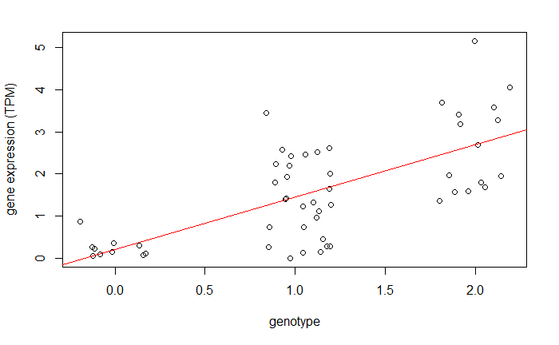

```r
intercept <- mdl$coefficients[1]
beta <- mdl$coefficients[2]
s <- summary(mdl)
p.val <- s$coefficients["genos","Pr(>|t|)"]
plot(jitter(genos), expr, xlab="genotype", ylab="gene expression (TPM)")
abline(a=intercept, b=beta, col="red")
```

Now lets test all SNPs that are close (within 50kb) of the gene ENSG00000218537 for association.

First get the genotypes of all of the nearby SNPs.

```r
gene.row <- which(gene.tab$GENE.NAME == "ENSG00000218537")
start <- gene.tab$GENE.START[gene.row] - 50000
end <- gene.tab$GENE.END[gene.row] + 50000
snp.rows <- which(genotypes.tab$CHROM.POS >= start & genotypes.tab$CHROM.POS <= end)
genotypes <- genotype.matrix[snp.rows,]
n.snps <- nrow(genotypes)
```

Next perform linear regression of the genoypes of each SNP against the expression of the gene and make a histogram of the p-values.

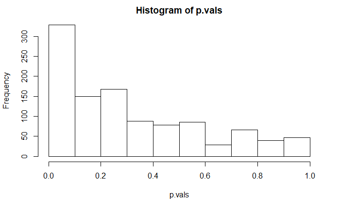

```r
p.vals <- rep(NA, n.snps)
for(i in seq(1, n.snps)) {
  genos <- unlist(genotypes[i,])
  mdl <- lm(expr ~ genos)
  s <- summary(mdl)
  p.vals[i] <- s$coefficients["genos","Pr(>|t|)"]
}
hist(p.vals)
```

Plot the genomic position of the SNPs (x-axis) against their -log10 p-values (y-axis)

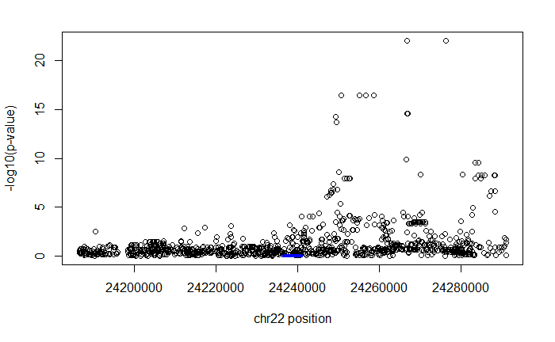

```r
pos <- genotypes.tab$CHROM.POS[snp.rows]
plot(pos, -log10(p.vals), ylab="-log10(p-value)", xlab="chr22 position")
# add the position of the gene
lines(x=c(gene.tab$GENE.START[gene.row], gene.tab$GENE.END[gene.row]), y=c(0,0),
         col="blue", lwd=4)
```